# 数学建模

## 内嵌环形饼图

我们先来回忆一下饼状图的绘制方法。

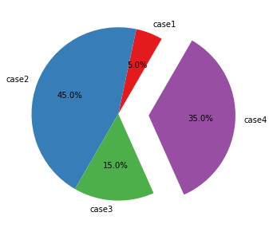

```python
import matplotlib.pyplot as plt
plt.figure(figsize=(5,5))

colors = ["#e41a1c","#377eb8","#4daf4a","#984ea3"]
soldNums = [0.05,0.45,0.15,0.35]
kinds = ['case1','case2','case3','case4']

explode = (0,0,0,0.35)

plt.pie(soldNums,
        explode = explode,
       labels=kinds,
       autopct="%3.1f%%",
       startangle=60,
       colors=colors);
```

饼图不仅可以展示单一数据的分布情况，还可以通过内嵌式的环形饼图实现多个数据集之间的对比。

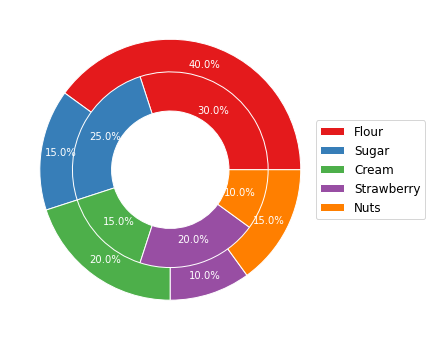

```python
import matplotlib.pyplot as plt
import numpy as np

plt.figure(figsize=(6,6))
elements = ["Flour","Sugar","Cream","Strawberry","Nuts"]

weight1 = [40,15,20,10,15]
weight2 = [30,25,15,20,10]

colormaplist = ["#e41a1c","#377eb8","#4daf4a","#984ea3","#ff7f00"]
outer_color = colormaplist
inner_color = colormaplist

wedges1,texts1,autotexts1 = plt.pie(weight1,
                                   autopct="%3.1f%%",
                                   radius=1,
                                   pctdistance=0.85,
                                   colors=outer_color,
                                   textprops=dict(color= "w"),
                                   wedgeprops=dict(width=0.3, edgecolor = 'w'))

wedges1,texts1,autotexts1 = plt.pie(weight2,
                                   autopct="%3.1f%%",
                                   radius=0.75,
                                   pctdistance=0.75,
                                   colors=outer_color,
                                   textprops=dict(color= "w"),
                                   wedgeprops=dict(width=0.3, edgecolor = 'w'))
plt.legend(wedges1,elements,fontsize = 12, loc = 'center right',bbox_to_anchor = (1,0,0.3,1))
```

## 箱线图

箱线图是由一个箱体和一对箱须所组成的统计图形。箱体是由第一四分位数、中位数（第二四分位数）、和第三四分位数组成的。在箱须末端之外的数值可以理解为离群值，因此，箱须是对一组数据范围的大致直观描述。

箱线图主要应用于一系列测量或者观测数据的比较场景中，例如学校间或班级间的测试成绩比较，球队中的队员体能对比，产品优化前后的测试比较以及同类产品的各项性能之间的比较等等。箱线图的应用非常广泛，实现也很简单。

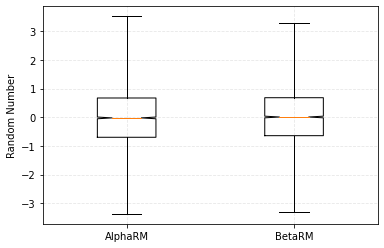

```python
import matplotlib.pyplot as plt
import numpy as np

testA = np.random.randn(5000)
testB = np.random.randn(5000)

testlist = [testA,testB]
labels = ["AlphaRM","BetaRM"]

whis = 2.5 # 四分位间距的倍数
width = 0.35

plt.boxplot(testlist,
           whis= whis,
           widths=width,
           sym='o',   # 离群值的标记样式
           labels=labels,
           notch=True,
           patch_artist=False); # 是否给箱体添加颜色
plt.ylabel('Random Number')

plt.grid(linestyle = '--',alpha = 0.3)
```

延伸阅读：箱体、箱须、离群值的含义和计算方法

- [箱线图](https://baike.baidu.com/item/%E7%AE%B1%E5%BD%A2%E5%9B%BE/10671164?fromtitle=%E7%AE%B1%E7%BA%BF%E5%9B%BE&fromid=10101649)
- [箱线图，维基百科](https://zh.wikipedia.org/zh-hans/%E7%AE%B1%E5%BD%A2%E5%9C%96)

# 完善统计图形

## 添加图例和标题

在绘图区域可能有多个图形，而这些图形如果不加说明，观察者则很难辨识出这些图形的主要内容。因此，我们需要对这些图形添加标签进行说明，这些标签就是图例。同样，一个言简意赅的标题同样能够帮助观察者了解图形的绘制内容。

### 图例和标题的设置方法

图例和标签的设置主要使用`legend()`和`title()`方法

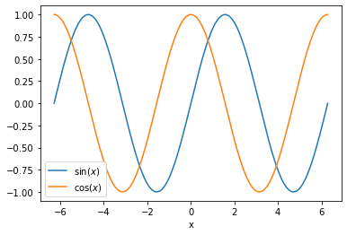

```python
import numpy as np
import matplotlib.pyplot as plt
%matplotlib inline

x = np.linspace(-2*np.pi,2*np.pi,200)
y = np.sin(x)
y1 = np.cos(x)

plt.plot(x,y,label = "$\sin(x)$")
plt.plot(x,y1,label = "$\cos(x)$")
plt.xlabel(r'x')
plt.legend()
```

## 图形大小、字体和字号的设置

有的时候我们想调整图形的字号大小，方便观察。

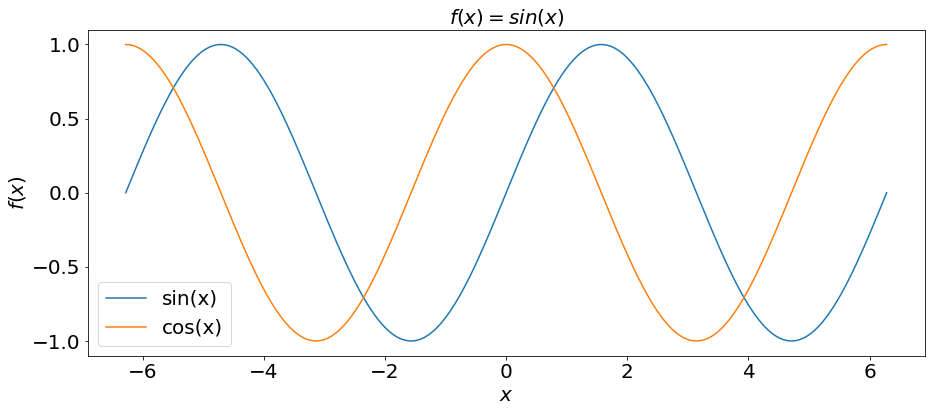

```python
plt.figure(figsize=(15,6))  # 设置图像的大小
x = np.linspace(-2*np.pi,2*np.pi,200)
y = np.sin(x)
y1 = np.cos(x)
plt.plot(x,y,label = 'sin(x)')
plt.plot(x,y1,label = 'cos(x)')
plt.legend(fontsize = 20)  # 设置图例的大小
plt.title('$f(x) = sin(x)$',fontsize = 20)  # 设置标题的大小
plt.tick_params(labelsize=20)  # 设置刻度的字体大小
plt.xlabel(r'$x$',fontsize = 20)  # 设置横轴标签的字体大小
plt.ylabel(r'$f(x)$',fontsize = 20)  # 设置纵轴标签的字体大小
```

## 多个子图的绘制

子图的本质是将绘图区划分为网格，在纵横交错的并列网格中，添加绘图坐标轴。实现了一张画图绘制多张图片。

### 函数`subplot()`：绘制网格区域中的几何形状相同的子区布局

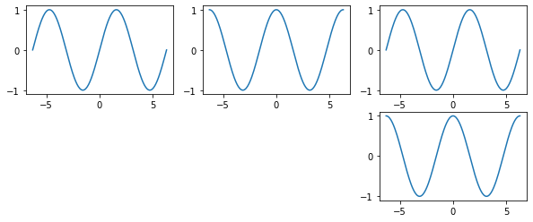

```python
import numpy as np
import matplotlib.pyplot as plt

x = np.linspace(-2*np.pi,2*np.pi,200)
plt.figure(figsize=(10,4))
y = np.sin(x)
y1 = np.cos(x)


plt.subplot(2,3,1)
plt.plot(x,y,label = "$\sin(x)$")



plt.subplot(2,3,2)
plt.plot(x,y1,label = "$\cos(x)$")

plt.subplot(2,3,3)
plt.plot(x,y,label = "$\sin(x)$")
plt.subplot(2,3,6)
plt.plot(x,y1,label = "$\cos(x)$")
#plt.savefig('test1.pdf')
```

# 实用案例：多个统计图形的组合展示

这里介绍一个一种可行的写法，不过新手也可以单独绘制每一张图，然后将其手动拼合在一起。

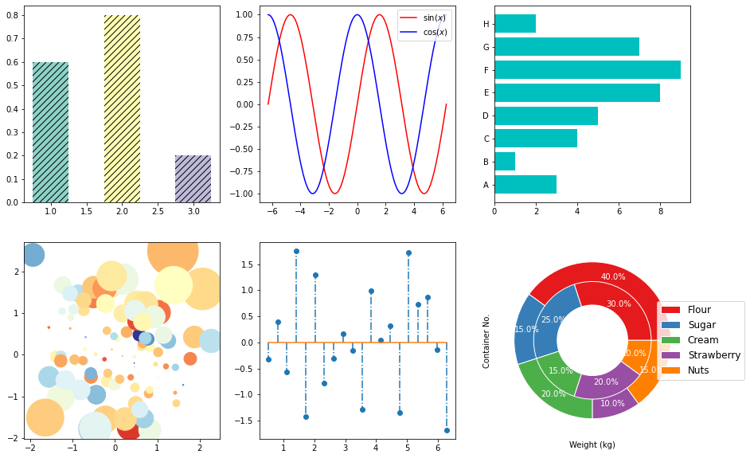

```python
import matplotlib.pyplot as plt
import numpy as np
fig,ax = plt.subplots(2,3,figsize = (15,10))

# subplot(2,3,1)
colors = ['#8dd3c7','#ffffb3','#bebada']
ax[0,0].bar([1,2,3],[0.6,0.8,0.2],color = colors, width = 0.5, hatch = '///',align = 'center')

# subplot(2,3,2)
x = np.linspace(-2*np.pi,2*np.pi,200)
y = np.sin(x)
y1 = np.cos(x)
ax[0,1].plot(x,y,'r',label = "$\sin(x)$")
ax[0,1].plot(x,y1,'b',label = "$\cos(x)$")
ax[0,1].legend()  # 设置图例的大小
plt.xlabel('$x$')  # 设置横轴标签的字体大小
plt.ylabel('$f(x)$')  # 设置纵轴标签的字体大小

# subplot(2,3,3)
x = [1,2,3,4,5,6,7,8]
y = [3,1,4,5,8,9,7,2]

ax[0,2].barh(x,y,align='center',color='c',tick_label = ['A','B','C','D','E','F','G','H'])

plt.ylabel('Container No.')
plt.xlabel('Weight (kg)')

# subplot(2,3,4)
import matplotlib as mpl
a = np.random.randn(100)
b = np.random.randn(100)

ax[1,0].scatter(a,b,
           s=np.power(10*a+20*b,2),
           c = np.random.randn(100),
           cmap=mpl.cm.RdYlBu,
           marker='o')

# subplot(2,3,5)
x = np.linspace(0.5,2*np.pi,20)
y = np.random.randn(20)

ax[1,1].stem(x,y,linefmt = '-.', markerfmt = 'o', basefmt = '-')



# subplot(2,3,6)
elements = ["Flour","Sugar","Cream","Strawberry","Nuts"]

weight1 = [40,15,20,10,15]
weight2 = [30,25,15,20,10]

colormaplist = ["#e41a1c","#377eb8","#4daf4a","#984ea3","#ff7f00"]
outer_color = colormaplist
inner_color = colormaplist

wedges1,texts1,autotexts1 = ax[1,2].pie(weight1,
                                   autopct="%3.1f%%",
                                   radius=1,
                                   pctdistance=0.85,
                                   colors=outer_color,
                                   textprops=dict(color= "w"),
                                   wedgeprops=dict(width=0.3, edgecolor = 'w'))

wedges1,texts1,autotextdds1 = ax[1,2].pie(weight2,
                                   autopct="%3.1f%%",
                                   radius=0.75,
                                   pctdistance=0.75,
                                   colors=outer_color,
                                   textprops=dict(color= "w"),
                                   wedgeprops=dict(width=0.3, edgecolor = 'w'))
plt.legend(wedges1,elements,fontsize = 12, loc = 'center right',bbox_to_anchor = (1,0,0.3,1))
# plt.savefig('group.pdf')
```

## 课后作业

课后作业 1.绘制函数图像

$$ f(x) = \sin^2(x−2)e^{−x^2} ,x \in [0,2] $$

加上适当的标题，坐标轴说明。

2.按照如下要求，以2*2的比例绘制成一个大图（注意给每个图片加上$x$轴，$y$轴，和标题）。

- $f(x) = \sin(x)$的曲线图
- 课堂练习中绘制的柱状图
- 课堂练习中绘制的饼状图
- 任意一个课程学到的，你想重现的图形